# Risk Factor Analysis

## Outcome Variable

**Outcome Variable:** y_rate_len

## Predictor Variables

**Intervention Variable:** fhtcm

**Adjustment Set:**

- arm
- W_mage
- W_fage
- meducyrs
- feducyrs
- W_mhtcm
- W_mwtkg
- W_mbmi
- single
- delta_W_fage
- delta_meducyrs
- delta_feducyrs
- delta_W_mhtcm
- delta_W_mwtkg
- delta_W_mbmi
- delta_single

## Stratifying Variables

The analysis was stratified on these variable(s):

- agecat
- studyid
- country

## Data Summary

| agecat | studyid | country | fhtcm | n_cell | n |
| --- | --- | --- | --- | --- | --- |
| 0-3 months | ki1000304b-SAS-CompFeed | INDIA | >=167 cm | 326 | 716 |
| 0-3 months | ki1000304b-SAS-CompFeed | INDIA | <162 cm | 184 | 716 |
| 0-3 months | ki1000304b-SAS-CompFeed | INDIA | [162-167) cm | 206 | 716 |
| 0-3 months | ki1101329-Keneba | GAMBIA | >=167 cm | 631 | 965 |
| 0-3 months | ki1101329-Keneba | GAMBIA | <162 cm | 75 | 965 |
| 0-3 months | ki1101329-Keneba | GAMBIA | [162-167) cm | 259 | 965 |
| 0-3 months | ki1119695-PROBIT | BELARUS | >=167 cm | 10773 | 11500 |
| 0-3 months | ki1119695-PROBIT | BELARUS | <162 cm | 151 | 11500 |
| 0-3 months | ki1119695-PROBIT | BELARUS | [162-167) cm | 576 | 11500 |
| 0-3 months | ki1135781-COHORTS | GUATEMALA | >=167 cm | 25 | 180 |
| 0-3 months | ki1135781-COHORTS | GUATEMALA | <162 cm | 106 | 180 |
| 0-3 months | ki1135781-COHORTS | GUATEMALA | [162-167) cm | 49 | 180 |
| 3-6 months | ki1000304b-SAS-CompFeed | INDIA | >=167 cm | 308 | 682 |
| 3-6 months | ki1000304b-SAS-CompFeed | INDIA | <162 cm | 175 | 682 |
| 3-6 months | ki1000304b-SAS-CompFeed | INDIA | [162-167) cm | 199 | 682 |
| 3-6 months | ki1101329-Keneba | GAMBIA | >=167 cm | 673 | 1037 |
| 3-6 months | ki1101329-Keneba | GAMBIA | <162 cm | 74 | 1037 |
| 3-6 months | ki1101329-Keneba | GAMBIA | [162-167) cm | 290 | 1037 |
| 3-6 months | ki1119695-PROBIT | BELARUS | >=167 cm | 9473 | 10104 |
| 3-6 months | ki1119695-PROBIT | BELARUS | <162 cm | 129 | 10104 |
| 3-6 months | ki1119695-PROBIT | BELARUS | [162-167) cm | 502 | 10104 |
| 3-6 months | ki1135781-COHORTS | GUATEMALA | >=167 cm | 37 | 261 |
| 3-6 months | ki1135781-COHORTS | GUATEMALA | <162 cm | 148 | 261 |
| 3-6 months | ki1135781-COHORTS | GUATEMALA | [162-167) cm | 76 | 261 |
| 6-12 months | ki1000304b-SAS-CompFeed | INDIA | >=167 cm | 313 | 679 |
| 6-12 months | ki1000304b-SAS-CompFeed | INDIA | <162 cm | 164 | 679 |
| 6-12 months | ki1000304b-SAS-CompFeed | INDIA | [162-167) cm | 202 | 679 |
| 6-12 months | ki1000304b-SAS-FoodSuppl | INDIA | >=167 cm | 89 | 328 |
| 6-12 months | ki1000304b-SAS-FoodSuppl | INDIA | <162 cm | 132 | 328 |
| 6-12 months | ki1000304b-SAS-FoodSuppl | INDIA | [162-167) cm | 107 | 328 |
| 6-12 months | ki1101329-Keneba | GAMBIA | >=167 cm | 635 | 1005 |
| 6-12 months | ki1101329-Keneba | GAMBIA | <162 cm | 78 | 1005 |
| 6-12 months | ki1101329-Keneba | GAMBIA | [162-167) cm | 292 | 1005 |
| 6-12 months | ki1119695-PROBIT | BELARUS | >=167 cm | 9248 | 9870 |
| 6-12 months | ki1119695-PROBIT | BELARUS | <162 cm | 124 | 9870 |
| 6-12 months | ki1119695-PROBIT | BELARUS | [162-167) cm | 498 | 9870 |
| 6-12 months | ki1135781-COHORTS | GUATEMALA | >=167 cm | 45 | 329 |
| 6-12 months | ki1135781-COHORTS | GUATEMALA | <162 cm | 192 | 329 |
| 6-12 months | ki1135781-COHORTS | GUATEMALA | [162-167) cm | 92 | 329 |
| 12-24 months | ki1101329-Keneba | GAMBIA | >=167 cm | 583 | 931 |
| 12-24 months | ki1101329-Keneba | GAMBIA | <162 cm | 73 | 931 |
| 12-24 months | ki1101329-Keneba | GAMBIA | [162-167) cm | 275 | 931 |
| 12-24 months | ki1119695-PROBIT | BELARUS | >=167 cm | 2169 | 2320 |
| 12-24 months | ki1119695-PROBIT | BELARUS | <162 cm | 38 | 2320 |
| 12-24 months | ki1119695-PROBIT | BELARUS | [162-167) cm | 113 | 2320 |
| 12-24 months | ki1135781-COHORTS | GUATEMALA | >=167 cm | 58 | 421 |
| 12-24 months | ki1135781-COHORTS | GUATEMALA | <162 cm | 244 | 421 |
| 12-24 months | ki1135781-COHORTS | GUATEMALA | [162-167) cm | 119 | 421 |

The following strata were considered:

- agecat: 0-3 months, studyid: ki1000304b-SAS-CompFeed, country: INDIA
- agecat: 0-3 months, studyid: ki1101329-Keneba, country: GAMBIA
- agecat: 0-3 months, studyid: ki1119695-PROBIT, country: BELARUS
- agecat: 0-3 months, studyid: ki1135781-COHORTS, country: GUATEMALA
- agecat: 12-24 months, studyid: ki1101329-Keneba, country: GAMBIA
- agecat: 12-24 months, studyid: ki1119695-PROBIT, country: BELARUS
- agecat: 12-24 months, studyid: ki1135781-COHORTS, country: GUATEMALA
- agecat: 3-6 months, studyid: ki1000304b-SAS-CompFeed, country: INDIA
- agecat: 3-6 months, studyid: ki1101329-Keneba, country: GAMBIA
- agecat: 3-6 months, studyid: ki1119695-PROBIT, country: BELARUS
- agecat: 3-6 months, studyid: ki1135781-COHORTS, country: GUATEMALA
- agecat: 6-12 months, studyid: ki1000304b-SAS-CompFeed, country: INDIA
- agecat: 6-12 months, studyid: ki1000304b-SAS-FoodSuppl, country: INDIA
- agecat: 6-12 months, studyid: ki1101329-Keneba, country: GAMBIA
- agecat: 6-12 months, studyid: ki1119695-PROBIT, country: BELARUS
- agecat: 6-12 months, studyid: ki1135781-COHORTS, country: GUATEMALA

## Methods Detail

We’re interested in the causal parameters $E[Y_a]$ for all values of $a \in \mathcal{A}$. These parameters represent the mean outcome if, possibly contrary to fact, we intervened to set all units to have $A=a$. Under the randomization and positivity assumptions, these are identified by the statistical parameters $\psi_a=E_W[E_{Y|A,W}(Y|A=a,W)]$. In addition, we’re interested in the mean of $Y$, $E[Y]$ under no intervention (the observed mean). We will estimate these parameters by using SuperLearner to fit the relevant likelihood factors – $E_{Y|A,W}(Y|A=a,W)$ and $p(A=a|W)$, and then updating our likelihood fit using a joint TMLE.

For unadjusted analyses ($W=\{\}$), initial likelihoods were estimated using Lrnr_glm to estimate the simple $E(Y|A)$ and Lrnr_mean to estimate $p(A)$. For adjusted analyses, a small library containing Lrnr_glmnet, Lrnr_xgboost, and Lrnr_mean was used.

# Results Detail

## Results Plots

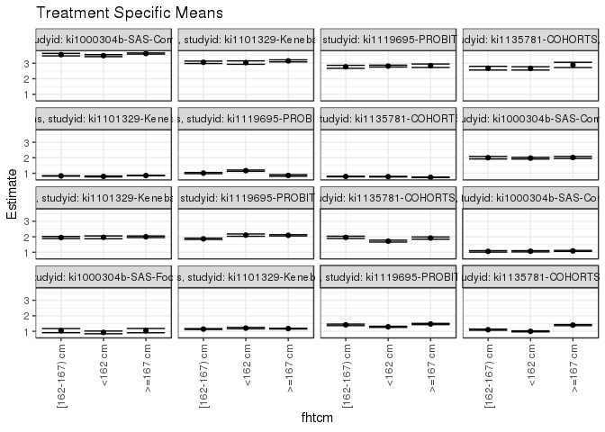

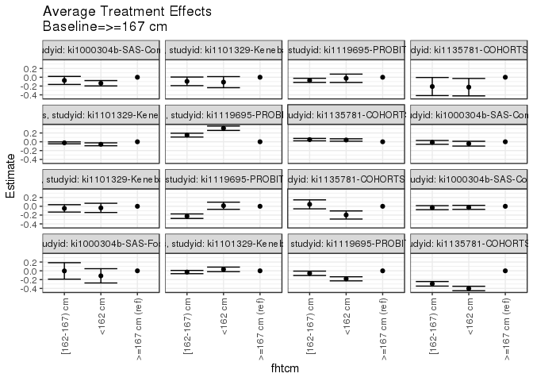

## Results Table

### Parameter: TSM

| agecat | studyid | country | intervention_level | baseline_level | estimate | ci_lower | ci_upper |
| --- | --- | --- | --- | --- | --- | --- | --- |
| 0-3 months | ki1000304b-SAS-CompFeed | INDIA | >=167 cm | NA | 3.6265579 | 3.5897823 | 3.6633335 |
| 0-3 months | ki1000304b-SAS-CompFeed | INDIA | <162 cm | NA | 3.4897745 | 3.4261235 | 3.5534256 |
| 0-3 months | ki1000304b-SAS-CompFeed | INDIA | [162-167) cm | NA | 3.5541379 | 3.4734074 | 3.6348684 |
| 0-3 months | ki1101329-Keneba | GAMBIA | >=167 cm | NA | 3.1533553 | 3.0879859 | 3.2187247 |
| 0-3 months | ki1101329-Keneba | GAMBIA | <162 cm | NA | 3.0421713 | 2.9321766 | 3.1521660 |
| 0-3 months | ki1101329-Keneba | GAMBIA | [162-167) cm | NA | 3.0599233 | 2.9836739 | 3.1361727 |
| 0-3 months | ki1119695-PROBIT | BELARUS | >=167 cm | NA | 2.8397992 | 2.7283446 | 2.9512539 |
| 0-3 months | ki1119695-PROBIT | BELARUS | <162 cm | NA | 2.8164569 | 2.7564627 | 2.8764512 |
| 0-3 months | ki1119695-PROBIT | BELARUS | [162-167) cm | NA | 2.7695982 | 2.6727388 | 2.8664577 |
| 0-3 months | ki1135781-COHORTS | GUATEMALA | >=167 cm | NA | 2.8930278 | 2.7234896 | 3.0625660 |
| 0-3 months | ki1135781-COHORTS | GUATEMALA | <162 cm | NA | 2.6675122 | 2.5605335 | 2.7744908 |
| 0-3 months | ki1135781-COHORTS | GUATEMALA | [162-167) cm | NA | 2.6814427 | 2.5623857 | 2.8004996 |
| 3-6 months | ki1000304b-SAS-CompFeed | INDIA | >=167 cm | NA | 2.0185736 | 1.9534909 | 2.0836562 |
| 3-6 months | ki1000304b-SAS-CompFeed | INDIA | <162 cm | NA | 1.9752913 | 1.9201482 | 2.0304344 |
| 3-6 months | ki1000304b-SAS-CompFeed | INDIA | [162-167) cm | NA | 2.0048788 | 1.9242897 | 2.0854679 |
| 3-6 months | ki1101329-Keneba | GAMBIA | >=167 cm | NA | 1.9994044 | 1.9477729 | 2.0510360 |
| 3-6 months | ki1101329-Keneba | GAMBIA | <162 cm | NA | 1.9630209 | 1.8705633 | 2.0554785 |
| 3-6 months | ki1101329-Keneba | GAMBIA | [162-167) cm | NA | 1.9520706 | 1.8842542 | 2.0198870 |
| 3-6 months | ki1119695-PROBIT | BELARUS | >=167 cm | NA | 2.0940789 | 2.0531524 | 2.1350054 |
| 3-6 months | ki1119695-PROBIT | BELARUS | <162 cm | NA | 2.1067212 | 2.0333732 | 2.1800693 |
| 3-6 months | ki1119695-PROBIT | BELARUS | [162-167) cm | NA | 1.8691152 | 1.8252137 | 1.9130167 |
| 3-6 months | ki1135781-COHORTS | GUATEMALA | >=167 cm | NA | 1.9173003 | 1.8464854 | 1.9881152 |
| 3-6 months | ki1135781-COHORTS | GUATEMALA | <162 cm | NA | 1.7196855 | 1.6584461 | 1.7809248 |
| 3-6 months | ki1135781-COHORTS | GUATEMALA | [162-167) cm | NA | 1.9616084 | 1.8873733 | 2.0358435 |
| 6-12 months | ki1000304b-SAS-CompFeed | INDIA | >=167 cm | NA | 1.0895533 | 1.0588052 | 1.1203013 |
| 6-12 months | ki1000304b-SAS-CompFeed | INDIA | <162 cm | NA | 1.0654498 | 1.0254167 | 1.1054829 |
| 6-12 months | ki1000304b-SAS-CompFeed | INDIA | [162-167) cm | NA | 1.0582466 | 1.0124882 | 1.1040051 |
| 6-12 months | ki1000304b-SAS-FoodSuppl | INDIA | >=167 cm | NA | 1.0440822 | 0.9045707 | 1.1835936 |
| 6-12 months | ki1000304b-SAS-FoodSuppl | INDIA | <162 cm | NA | 0.9299315 | 0.8430042 | 1.0168589 |
| 6-12 months | ki1000304b-SAS-FoodSuppl | INDIA | [162-167) cm | NA | 1.0417100 | 0.9100304 | 1.1733896 |
| 6-12 months | ki1101329-Keneba | GAMBIA | >=167 cm | NA | 1.1733968 | 1.1485216 | 1.1982720 |
| 6-12 months | ki1101329-Keneba | GAMBIA | <162 cm | NA | 1.2062541 | 1.1601295 | 1.2523787 |
| 6-12 months | ki1101329-Keneba | GAMBIA | [162-167) cm | NA | 1.1453805 | 1.1176705 | 1.1730906 |
| 6-12 months | ki1119695-PROBIT | BELARUS | >=167 cm | NA | 1.4714077 | 1.4324644 | 1.5103511 |
| 6-12 months | ki1119695-PROBIT | BELARUS | <162 cm | NA | 1.2892443 | 1.2528602 | 1.3256284 |
| 6-12 months | ki1119695-PROBIT | BELARUS | [162-167) cm | NA | 1.4149485 | 1.3651174 | 1.4647797 |
| 6-12 months | ki1135781-COHORTS | GUATEMALA | >=167 cm | NA | 1.3997023 | 1.3629344 | 1.4364702 |
| 6-12 months | ki1135781-COHORTS | GUATEMALA | <162 cm | NA | 0.9978704 | 0.9644377 | 1.0313031 |
| 6-12 months | ki1135781-COHORTS | GUATEMALA | [162-167) cm | NA | 1.1042737 | 1.0674371 | 1.1411103 |
| 12-24 months | ki1101329-Keneba | GAMBIA | >=167 cm | NA | 0.8548072 | 0.8398902 | 0.8697242 |
| 12-24 months | ki1101329-Keneba | GAMBIA | <162 cm | NA | 0.7972269 | 0.7670297 | 0.8274241 |
| 12-24 months | ki1101329-Keneba | GAMBIA | [162-167) cm | NA | 0.8304382 | 0.8140126 | 0.8468639 |
| 12-24 months | ki1119695-PROBIT | BELARUS | >=167 cm | NA | 0.8616446 | 0.8104902 | 0.9127990 |
| 12-24 months | ki1119695-PROBIT | BELARUS | <162 cm | NA | 1.1687671 | 1.1258328 | 1.2117015 |
| 12-24 months | ki1119695-PROBIT | BELARUS | [162-167) cm | NA | 1.0129911 | 0.9755309 | 1.0504513 |
| 12-24 months | ki1135781-COHORTS | GUATEMALA | >=167 cm | NA | 0.7411315 | 0.7202706 | 0.7619923 |
| 12-24 months | ki1135781-COHORTS | GUATEMALA | <162 cm | NA | 0.7813332 | 0.7627312 | 0.7999353 |
| 12-24 months | ki1135781-COHORTS | GUATEMALA | [162-167) cm | NA | 0.7896443 | 0.7707458 | 0.8085429 |

### Parameter: E(Y)

| agecat | studyid | country | intervention_level | baseline_level | estimate | ci_lower | ci_upper |
| --- | --- | --- | --- | --- | --- | --- | --- |
| 0-3 months | ki1000304b-SAS-CompFeed | INDIA | NA | NA | 3.5844413 | 3.5457307 | 3.6231519 |
| 0-3 months | ki1101329-Keneba | GAMBIA | NA | NA | 3.1289757 | 3.0738379 | 3.1841134 |
| 0-3 months | ki1119695-PROBIT | BELARUS | NA | NA | 2.8334708 | 2.7205961 | 2.9463455 |
| 0-3 months | ki1135781-COHORTS | GUATEMALA | NA | NA | 2.6646531 | 2.5748250 | 2.7544813 |
| 3-6 months | ki1000304b-SAS-CompFeed | INDIA | NA | NA | 1.9381168 | 1.8722991 | 2.0039344 |
| 3-6 months | ki1101329-Keneba | GAMBIA | NA | NA | 1.9794873 | 1.9347361 | 2.0242384 |
| 3-6 months | ki1119695-PROBIT | BELARUS | NA | NA | 2.0916969 | 2.0506004 | 2.1327933 |
| 3-6 months | ki1135781-COHORTS | GUATEMALA | NA | NA | 1.7979953 | 1.7423030 | 1.8536877 |
| 6-12 months | ki1000304b-SAS-CompFeed | INDIA | NA | NA | 1.0908364 | 1.0624756 | 1.1191972 |
| 6-12 months | ki1000304b-SAS-FoodSuppl | INDIA | NA | NA | 0.9947133 | 0.9228294 | 1.0665973 |
| 6-12 months | ki1101329-Keneba | GAMBIA | NA | NA | 1.1722791 | 1.1516434 | 1.1929147 |
| 6-12 months | ki1119695-PROBIT | BELARUS | NA | NA | 1.4698038 | 1.4307195 | 1.5088880 |
| 6-12 months | ki1135781-COHORTS | GUATEMALA | NA | NA | 0.9973638 | 0.9680912 | 1.0266364 |
| 12-24 months | ki1101329-Keneba | GAMBIA | NA | NA | 0.8443568 | 0.8321723 | 0.8565414 |
| 12-24 months | ki1119695-PROBIT | BELARUS | NA | NA | 0.8608646 | 0.8094654 | 0.9122639 |
| 12-24 months | ki1135781-COHORTS | GUATEMALA | NA | NA | 0.7934317 | 0.7769015 | 0.8099619 |

### Parameter: ATE

| agecat | studyid | country | intervention_level | baseline_level | estimate | ci_lower | ci_upper |
| --- | --- | --- | --- | --- | --- | --- | --- |
| 0-3 months | ki1000304b-SAS-CompFeed | INDIA | >=167 cm | >=167 cm | 0.0000000 | 0.0000000 | 0.0000000 |
| 0-3 months | ki1000304b-SAS-CompFeed | INDIA | <162 cm | >=167 cm | -0.1367834 | -0.1976369 | -0.0759298 |
| 0-3 months | ki1000304b-SAS-CompFeed | INDIA | [162-167) cm | >=167 cm | -0.0724200 | -0.1639891 | 0.0191491 |
| 0-3 months | ki1101329-Keneba | GAMBIA | >=167 cm | >=167 cm | 0.0000000 | 0.0000000 | 0.0000000 |
| 0-3 months | ki1101329-Keneba | GAMBIA | <162 cm | >=167 cm | -0.1111840 | -0.2371796 | 0.0148116 |
| 0-3 months | ki1101329-Keneba | GAMBIA | [162-167) cm | >=167 cm | -0.0934320 | -0.1912801 | 0.0044161 |
| 0-3 months | ki1119695-PROBIT | BELARUS | >=167 cm | >=167 cm | 0.0000000 | 0.0000000 | 0.0000000 |
| 0-3 months | ki1119695-PROBIT | BELARUS | <162 cm | >=167 cm | -0.0233423 | -0.1183574 | 0.0716728 |
| 0-3 months | ki1119695-PROBIT | BELARUS | [162-167) cm | >=167 cm | -0.0702010 | -0.1169147 | -0.0234873 |
| 0-3 months | ki1135781-COHORTS | GUATEMALA | >=167 cm | >=167 cm | 0.0000000 | 0.0000000 | 0.0000000 |
| 0-3 months | ki1135781-COHORTS | GUATEMALA | <162 cm | >=167 cm | -0.2255156 | -0.4236945 | -0.0273367 |
| 0-3 months | ki1135781-COHORTS | GUATEMALA | [162-167) cm | >=167 cm | -0.2115851 | -0.4175216 | -0.0056487 |
| 3-6 months | ki1000304b-SAS-CompFeed | INDIA | >=167 cm | >=167 cm | 0.0000000 | 0.0000000 | 0.0000000 |
| 3-6 months | ki1000304b-SAS-CompFeed | INDIA | <162 cm | >=167 cm | -0.0432823 | -0.0975280 | 0.0109635 |
| 3-6 months | ki1000304b-SAS-CompFeed | INDIA | [162-167) cm | >=167 cm | -0.0136948 | -0.0568245 | 0.0294350 |
| 3-6 months | ki1101329-Keneba | GAMBIA | >=167 cm | >=167 cm | 0.0000000 | 0.0000000 | 0.0000000 |
| 3-6 months | ki1101329-Keneba | GAMBIA | <162 cm | >=167 cm | -0.0363836 | -0.1412089 | 0.0684418 |
| 3-6 months | ki1101329-Keneba | GAMBIA | [162-167) cm | >=167 cm | -0.0473338 | -0.1312676 | 0.0365999 |
| 3-6 months | ki1119695-PROBIT | BELARUS | >=167 cm | >=167 cm | 0.0000000 | 0.0000000 | 0.0000000 |
| 3-6 months | ki1119695-PROBIT | BELARUS | <162 cm | >=167 cm | 0.0126423 | -0.0687325 | 0.0940171 |
| 3-6 months | ki1119695-PROBIT | BELARUS | [162-167) cm | >=167 cm | -0.2249637 | -0.2762272 | -0.1737002 |
| 3-6 months | ki1135781-COHORTS | GUATEMALA | >=167 cm | >=167 cm | 0.0000000 | 0.0000000 | 0.0000000 |
| 3-6 months | ki1135781-COHORTS | GUATEMALA | <162 cm | >=167 cm | -0.1976148 | -0.2898538 | -0.1053757 |
| 3-6 months | ki1135781-COHORTS | GUATEMALA | [162-167) cm | >=167 cm | 0.0443081 | -0.0575784 | 0.1461946 |
| 6-12 months | ki1000304b-SAS-CompFeed | INDIA | >=167 cm | >=167 cm | 0.0000000 | 0.0000000 | 0.0000000 |
| 6-12 months | ki1000304b-SAS-CompFeed | INDIA | <162 cm | >=167 cm | -0.0241035 | -0.0701557 | 0.0219488 |
| 6-12 months | ki1000304b-SAS-CompFeed | INDIA | [162-167) cm | >=167 cm | -0.0313066 | -0.0769208 | 0.0143075 |
| 6-12 months | ki1000304b-SAS-FoodSuppl | INDIA | >=167 cm | >=167 cm | 0.0000000 | 0.0000000 | 0.0000000 |
| 6-12 months | ki1000304b-SAS-FoodSuppl | INDIA | <162 cm | >=167 cm | -0.1141506 | -0.2764199 | 0.0481186 |
| 6-12 months | ki1000304b-SAS-FoodSuppl | INDIA | [162-167) cm | >=167 cm | -0.0023722 | -0.1896491 | 0.1849047 |
| 6-12 months | ki1101329-Keneba | GAMBIA | >=167 cm | >=167 cm | 0.0000000 | 0.0000000 | 0.0000000 |
| 6-12 months | ki1101329-Keneba | GAMBIA | <162 cm | >=167 cm | 0.0328573 | -0.0189200 | 0.0846346 |
| 6-12 months | ki1101329-Keneba | GAMBIA | [162-167) cm | >=167 cm | -0.0280163 | -0.0644824 | 0.0084499 |
| 6-12 months | ki1119695-PROBIT | BELARUS | >=167 cm | >=167 cm | 0.0000000 | 0.0000000 | 0.0000000 |
| 6-12 months | ki1119695-PROBIT | BELARUS | <162 cm | >=167 cm | -0.1821634 | -0.2283788 | -0.1359480 |
| 6-12 months | ki1119695-PROBIT | BELARUS | [162-167) cm | >=167 cm | -0.0564592 | -0.1063363 | -0.0065821 |
| 6-12 months | ki1135781-COHORTS | GUATEMALA | >=167 cm | >=167 cm | 0.0000000 | 0.0000000 | 0.0000000 |
| 6-12 months | ki1135781-COHORTS | GUATEMALA | <162 cm | >=167 cm | -0.4018319 | -0.4519664 | -0.3516974 |
| 6-12 months | ki1135781-COHORTS | GUATEMALA | [162-167) cm | >=167 cm | -0.2954286 | -0.3477106 | -0.2431465 |
| 12-24 months | ki1101329-Keneba | GAMBIA | >=167 cm | >=167 cm | 0.0000000 | 0.0000000 | 0.0000000 |
| 12-24 months | ki1101329-Keneba | GAMBIA | <162 cm | >=167 cm | -0.0575803 | -0.0910020 | -0.0241585 |
| 12-24 months | ki1101329-Keneba | GAMBIA | [162-167) cm | >=167 cm | -0.0243690 | -0.0462037 | -0.0025342 |
| 12-24 months | ki1119695-PROBIT | BELARUS | >=167 cm | >=167 cm | 0.0000000 | 0.0000000 | 0.0000000 |
| 12-24 months | ki1119695-PROBIT | BELARUS | <162 cm | >=167 cm | 0.3071226 | 0.2574669 | 0.3567783 |
| 12-24 months | ki1119695-PROBIT | BELARUS | [162-167) cm | >=167 cm | 0.1513465 | 0.1080561 | 0.1946369 |
| 12-24 months | ki1135781-COHORTS | GUATEMALA | >=167 cm | >=167 cm | 0.0000000 | 0.0000000 | 0.0000000 |
| 12-24 months | ki1135781-COHORTS | GUATEMALA | <162 cm | >=167 cm | 0.0402018 | 0.0129754 | 0.0674281 |
| 12-24 months | ki1135781-COHORTS | GUATEMALA | [162-167) cm | >=167 cm | 0.0485128 | 0.0211902 | 0.0758355 |